# R包那些事儿

谢益辉  
2013/05/18 @ 北京，第6届中国R语言会议

### 中国R语言会议，2008-2013

- 第1届R会议，2008，中国人民大学
  - John Maindonald
- useR! 2008，多特蒙德
- animation，2007

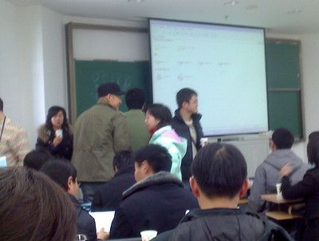

### 我的第1个R包：animation

### 想法

- 出于“好玩”的目的
  - 第一个动画作品：布朗运动（演示）
- 动画原理非常简单（演示）
  - 原始人看电影
  - 北京地铁广告

### 纯码农没有出路

- 统计学
  - 豌豆机（演示）
- John Chambers软件奖

### 界面（旧）

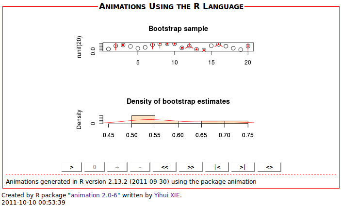

### 界面（新）

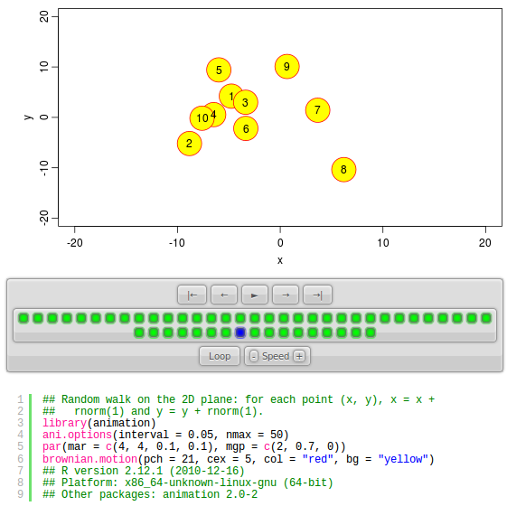

### 自动一切可自动化的配置

- saveGIF()与ImageMagick的安装目录
  - Windows下找软件的痛苦
- readRegistry()

[figure not shown]

### 文档优先级：参数说明 < 例子/演示

- `demo('fire', package = 'animation')`

### 文档优先级：R文档 < 网站

- 出国申请
  - 善易者不卜
- 死文档与活网站
  - 富媒体
  - 与用户的交互
  - 访问数据

### 如果你还不会做网站

听报告的这半小时花在学习HTML上更划算

### 动画网站

- 第一版：Dreamweaver，纯HTML，手码
- 第二版：Dokuwiki，简单语法，手工维护
- 第三版：Jekyll/Markdown，knitr动态生成，自动化
  - 打江山容易，守江山难
- [http://animation.yihui.name](http://vis.supstat.com/categories.html#Animation-ref)

### 好玩是第一生产力

- 演示
  - 那些年一起蜇我们的蜜蜂
  - Game of Life

### 第2-8个R包

- formatR
- iBUGS
- Rd2roxygen
- R2SWF
- fun
- MSG
- knitr

### 那些小需求

- 阅读他人代码的痛苦（格式）-> formatR
- 助教批作业的苦恼（重复运行代码太困难）-> knitr（演示）

### animation包的“中年危机”

- 实在不想维护，因为写文档太麻烦
  - 痛恨伪LaTeX
  - 文档和代码分开，需要翻来覆去死去活来
- 通向roxygen2之路：Rd2roxygen
  - `#' documentation`
  - 腰不酸了，腿不痛了，写代码也有力了

### 扎实帝C vs 酷炫帝JavaScript

- R2SWF：R图形转化为Flash动画
  - 一大波C代码即将来袭
  - 搭档小轩哥
- `animation::saveHTML()`
- 段王爷的工作

### 命名

- 史上最弱的名字：R
- 毫无想象力：animation
- highlight的痛苦
- knitr的由来
- google-able原则
  - lubridate

### 关于推销

- 除非你是萌主，否则
  - 相信群众的眼睛
  - 装作若无其事的样子暗推销

### 社交化

- 版本控制：论文20130501.doc的故事
- SVN vs GIT
- GitHub Pull Requests：拿代码来说话
- 代码评论与讨论

### 谢谢

- COS论坛：http://cos.name/cn
- [@统计之都](http://weibo.com/cosname) [@谢益辉](http://weibo.com/yihuixie)
- (http://|xie@)yihui.name